# Cat Encounter Study - Abundance & Enjoyability

## Figure.1: Total Cat Scores for months March and May

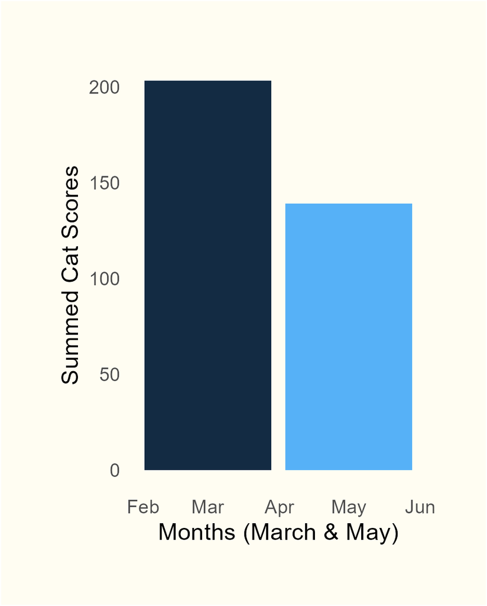

**Analysing Figure.1,** we can see that between the two months that data was collected (March and May), March as a month had a much larger sum of all cat scores recorded than the month of May.

The reasoning for this *could be* due to May typically being a colder month, where cats might not be as sociable due to the colder climate.

During colder times, cats adopt more frugal tactics when it comes to their affection towards humans, preferring to spend their time in warmer places rather than roaming in areas where people are able to pet them and therefore have better experiences (meaning higher cat score!). This theorised claim is supported by [Cat Chef, Amazing Cat Facts](https://catschef.com/how-do-outdoor-cats-survive-winter-15-fascinating-facts/).

## Figure.2: Relationship between the time of day and the correlating mean cat score

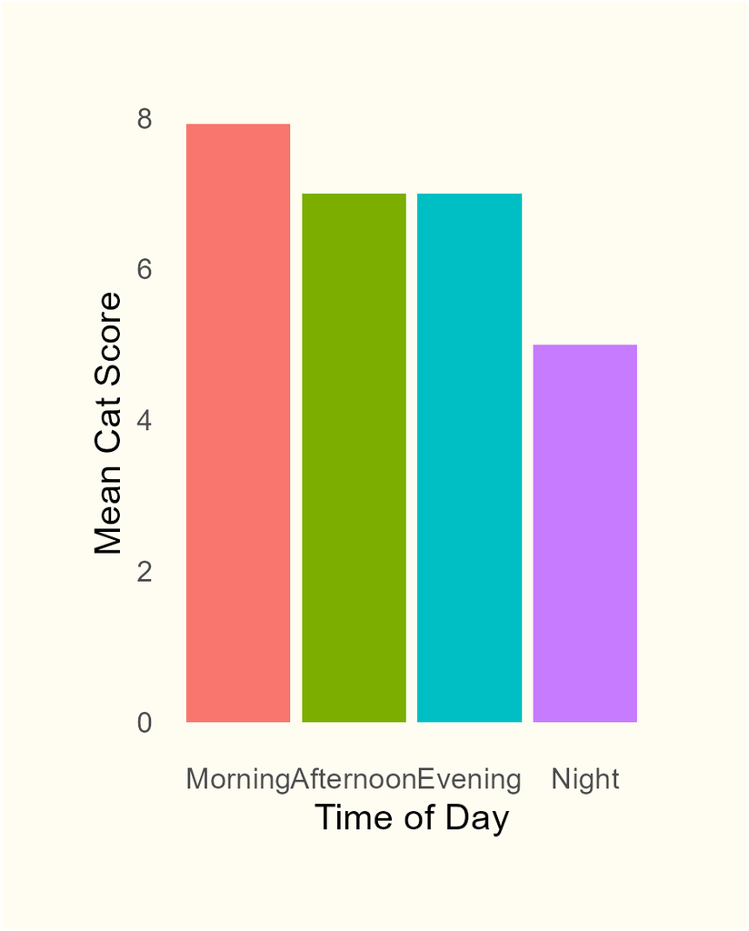

**Analysing Figure.2,** we see a much better model where we can infer the effect that time of day (and potentially temperature) has on the mean cat score recorded for that time of day.

The highest mean cat score was recorded to Morning hours between 5am and 12pm. This could have occurred due to cats having a crepuscular activity pattern, being most active during dawning and evening hours. It is during this time we would expect to see residential cats patrolling or hunting - meaning more sightings of cats, opportunities to pet them and therefore a higher mean cat score.

The graph overall demonstrates what seems to be a negative relationship betwdeen the mean cat score and the period of day - meaning that the peak cat scores are most likely to be recorded during the morning, and the lowest cat scores are most likely to be recored during night.

Mean cat scores for all periods of the day seem to be quite pawsitive since - how could you have a bad time seeing / petting cute residential kitty cats?

## Figure.3: A better view of The Realtionship between the Mean Cat Score and Time of Day

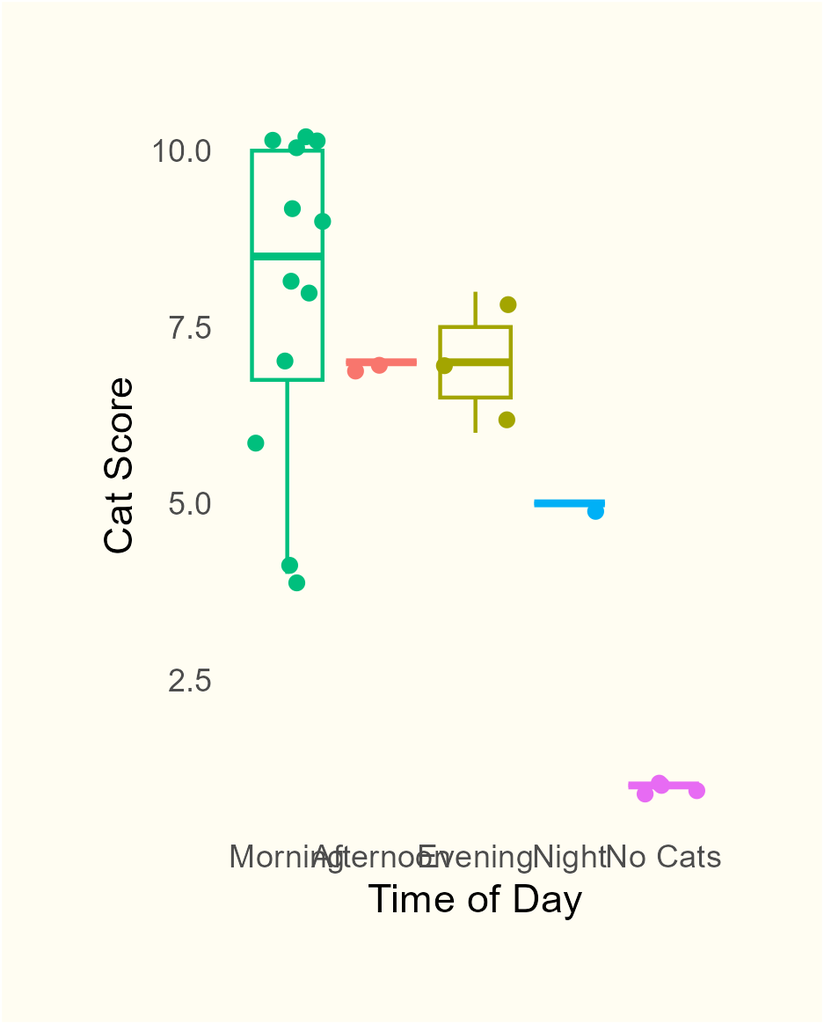

**Analysing Figure.3,** we can see a proper trend correlating between the time period of day and the mean cat score recorded.

It appears that cat scores recorded during the morning have the largest interquartile range and mean out of all of the time periods.

During the night time (8pm - 5am), the lowest mean score of 5 was recorded likely due to poor vision at night and inability to sight many cats and therefore have a positive experience (higher cat score).